# Distribuições de Probabilidade

Gabriela, Matheus, Vitor

04/05/2020

Além das análises utilizando estatísticas descritivas, o R contém pacotes que nos permitem trabalhar com probabilidades. Ao longo das disciplinas de estatística, vamos nos deparar com diversos exercícios de probabilidade, e o R é uma boa ferramenta para se fazer conferências referentes aos cálculos feitos nestes exercícios. Além do mais, a probabilidade no R amplia nossas possibilidades no âmbito dos estudos em que queremos checar o quão provável é a ocorrência de um evento, mas nem sempre conseguimos encontrar tais probabilidades efetuando cálculos à mão. Neste tópico vamos abordar três distribuições conhecidas, são elas: Poison (Variável discreta), Binomial (Variável discreta) e Normal (Variável contínua). Nos pacotes referentes a cada modelo encontramos funções que calculam os quantis das distribuições e probabilidades exatas, dados os parâmetros de cada distribuição.

## 5.1 Binomial

Um dos principais modelos discretos de probabilidade é o modelo *Binomial*. Quando possuímos uma sequência de *n* experimentos independentes entre si,com variáveis binárias como resposta (sucesso ou fracasso), dada uma determinada probabilidade constante de sucesso, podemos obter a probabilidade de ocorrência de *k* sucessos através da distribuição binomial.

**Contextualizando**

Em uma fábrica de empacotar café, espera-se que o peso do produto final esteja entre 498 e 502 gramas. Cerca de 90% das embalagens continham a quantidade de café dentro dos padrões desejados. Se escolhermos aleatoriamente 10 embalagens, podemos muito bem encontrar 10 pacotes de café com o peso aceitável. Entretanto, pode ser também que, na nossa amostra, nenhum pacote esteja dentro desse padrão.

Mas como mensurar as probabiliidades desses eventos? Eles são prováveis ou não? Podemos perfeitamente calcular as probabilidades desejadas usando o modelo binomial: neste caso, nosso n seria igual a 10 e p seria 0.90, assumindo que a exposição referente quantidade de café seja independente para cada indivíduo da nossa amostra.

$$P(X=k) = \frac{n!}{k!(n-k)!}p^k(1-p)^{n-k}$$
### 5.1.1 Função dbinom

Suponha que na nossa amostra de 10 pacotes, n = 10, estejamos interessados na probabilidade de encontrarmos 8 pacotes com peso ideal, k =8, com p =0.90. Calculamos a probabilidade P(X = 8 ) da seguinte maneira:

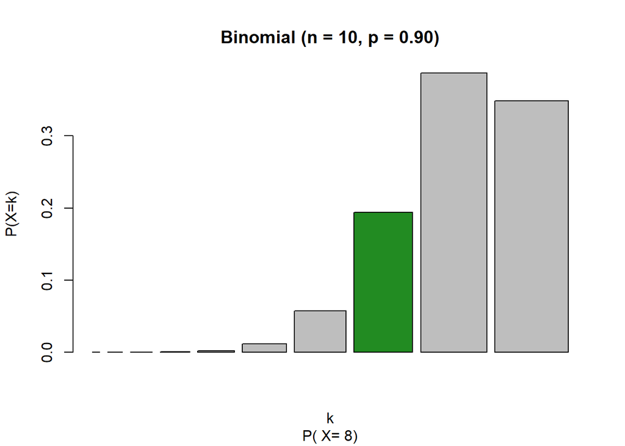

```r
dbinom(x = 8, size = 10, prob = 0.9)
```

```
## [1] 0.1937102
```

E para P(X =9)?

```r
dbinom(x = 9, size = 10, prob = 0.9)
```

```
## [1] 0.3874205
```

Repare que o argumento size em dbinom representa o número de replicações do experimento (peso ideal ou não), referente ao parâmetro *n* da binomial.